# Data Exploration of Food and Agricultural Organization

Kaitlyn Parks

9/21/2022

This file contains one student’s fledgling attempt to wrangle data and create interesting and useful graphics to illustrate my comprehension in R.

```r
library(tidyverse)
library(readr)
library(dplyr)
library(RColorBrewer)
library(rcartocolor)
library(kableExtra)
library(patchwork)
library(ggplot2)
library(dplyr)
```

## The Data

The Food and Agriculture Organization of the United Nations (FAO) supports governments and other organizations to design policies and programs to end hunger, promote food security, and enhance sustainable agriculture around the world. They collect data about food and agriculture for over 245 countries and territories.

I pulled data from their Suite of Food Insecurity Indicators. This set can be filtered by country and specific indicators related to food access, food supply stability and utilization, and overall prevalence of food insecurity malnutrition, etc.

I initially wanted to look at a handful of Middle Eastern countries, but found that many of these countries are missing key data points. This was an issue that continually thwarted data wrangling progess. It makes sense that these data are most often missing from the poorest countries - basic needs resources are already lacking or extremely fragile, making data collection less of a priority for governments.

## Moderate and Severe Food Insecurity around the World

Some helpful definitions to orient us to this data:

The FAO definition of food insecurity is: “A situation that exists when people lack secure access to sufficient amounts of safe and nutritious food for normal growth and development and an active and healthy life.”

The FAO uses a multidemential index to “score” food insecurity levels. “Moderate” food insecurity may invovle reduced foo intake and the experience of hunger due to self-rationing. “Severe” food insecurity describes more acute physical sensations of hunger and potentially evidence of malnutrition as a resuld of muched reduced food intake. For the most, these visualizations look at combined prevalence of moderate and severe food insecurity, though sometimes explore severe food insecurity specifically.

Consider how rates of food insecurity vary around the world:

```r
world <- read_csv("FAOSTAT_data_en_10-3-2022.csv")

world2 <- world %>%
  select(isocode = `Area Code (M49)`,  Region = Area,
         itemcode = `Item Code`, year = `Year Code`,
         yearlabel = Year, value = Value) %>%
  pivot_wider(names_from = itemcode, values_from = value) %>%
  rename(severe_percent = `210400`, moderate_percent = `210090`)

world2 %>%
  select(Region, moderate_percent) %>%
  kbl(align = "c") %>%
  kable_styling(bootstrap_options = c("striped", "hover")) %>%
  scroll_box(height = "300px")
```

| Region | moderate_percent |
| --- | --- |
| World | 29.3 |
| Africa | 57.9 |
| Northern America and Europe | 8.0 |
| Latin America and the Caribbean | 40.6 |
| Asia | 24.6 |
| Oceania | 13.0 |

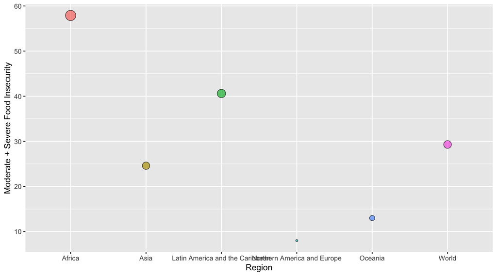

```r
world2 %>%
ggplot(aes(x=Region, y=moderate_percent, size = severe_percent, fill = Region)) +
    geom_point(alpha=0.7, shape=21) +
    theme(legend.position = "none")+
    ylab("Moderate + Severe Food Insecurity") +
    xlab("Region")
```

## Into Africa

In Africa, there are 278 million people facing hunger. 23% of the contininent is severely food insecure.

Countries in the Middle East and North Africa are among the most at risk of famine on the planet. Already a hotspot of conflict, humanitarian crises, and socio-economic instability, with dangerously increasing temperatures, this region also suffers from food and water shortages, and livability of the area.

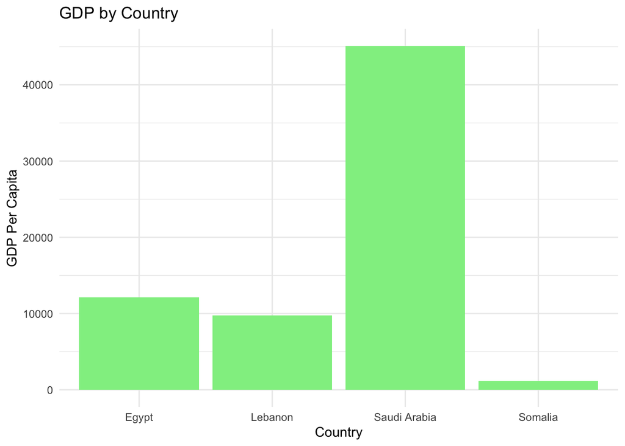

```r
UN <- read_csv("FAOSTAT_data_en_9-20-2022.csv") %>%
  filter(Item == "Gross domestic product per capita, PPP, (constant 2017 international $)") %>%
  mutate (pop="Total",
          `Item Code` = as.character(`Item Code`))

UN_wider <- UN%>%
  pivot_wider(names_from = Item, values_from = Value) %>%
  rename(GDP = `Gross domestic product per capita, PPP, (constant 2017 international $)`,
         country = Area)

UN_wider %>%
  ggplot(aes(x = country, y = GDP)) +
  geom_col(position = "dodge", fill = "light green") +
  theme_minimal () +
  labs(x = "Country", y = "GDP Per Capita",
       title = "GDP by Country")
```